# COVID-19 Cases and Deaths Throughout Maryland

A Tutorial on "The Data Science Pipeline"  
By Ryan Park

# Outline

1. Introduction
2. Setup Requirements
3. Data Collection
4. Data Management
5. Data Representation & Analysis
6. Hypothesis Testing
7. Machine Learning
8. Conclusion
9. References

# Introduction

According to this [Maryland news article](https://www.marylandmatters.org/2021/04/05/hogan-moves-to-open-the-vaccine-floodgates-expands-access-to-everyone-16-and-older/), COVID-19 vaccine providers were made available to people age 16 and older on April 12, 2021. COVID-19 has caused many deaths in the world for the past 1.5+ years and still persists today. As a Maryland, USA resident, I'm curious to how much the virus would continue to spread and cause death if vaccines were still unavailable by county.

Today I will be accessing Maryland's public data on COVID-19 by county while giving you a complete Data Science Tutorial.

This tutorial will walk you through a pipeline containing Data Collection, Data Management, Data Representation, Exploratory Data Analysis, Hypothesis Testing and Maching Learning, and Communication of Insights Attained/Conclusion.

**Feel free to use the outline above to skip around the tutorial.**

# Setup Requirements

Before we start doing anything too fancy, we must first make sure we have the right tools and files to get the job done.

1. We will be using the latest version of Python 3 and Jupyter Notebook.

> If you don't have Python 3 and/or Jupyter Notebook here's a couple links to help you out.  
> Python 3 Download: [Python 3](https://www.python.org/downloads/)  
> Anaconda Download: [Anaconda](https://www.anaconda.com/products/individual)  
> Platform Downloads (read both first): [Jupyter Notebook part 1/2](https://www.geeksforgeeks.org/how-to-install-jupyter-notebook-in-windows/) and [Jupyter Notebook part 2/2](https://jupyter.org/install)
1. We will need the following libraries from Python 3:

> Installing Python 3 and Anaconda should already download these for you so there should be no worries in accessing them (for now).
> - pandas
> - numpy
> - matplotlib.plyplot
> - statsmodels.formula.api
> - LinearRegressionfrom sklearn.linear_model
> - sklearn.model_selection
1. Maryland's data on COVID-19 is public and downloadable so we'll have to visit their site to get it.

> Instructions to gettting the data is as followed:
> 1. Click on this url [MD COVID-19 - Cases by County](https://opendata.maryland.gov/Health-and-Human-Services/MD-COVID-19-Cases-by-County/tm86-dujs).
> 2. Click the "Export" button on the top right corner of the page (under the "Sign In" button).
> 3. Click the "CSV" button to download the dataset.
> 4. Click on this url [MD COVID-19 - Confirmed Deaths by County](https://opendata.maryland.gov/Health-and-Human-Services/MD-COVID-19-Confirmed-Deaths-by-County/x28q-kc4a).
> 5. Repeat steps 2 and 3.

# Data Collection

### About the Data

The datasets contain information on the cumulative COVID-19 cases and deaths in each county of Maryland.

Since these two information are from separate datasets, we will need access and combine the two datasets into one so that it's easier to interpret the data visually.

### Importing Libraries

```python
import pandas as pd
import numpy as np
import matplotlib.pyplot as plt
import statsmodels.formula.api as sm
from sklearn.linear_model import LinearRegression
import sklearn.model_selection as ms
```

### Loading and Viewing The Data

Use the pandas library to read in the CSV (comma-separated values) files by giving pandas the path to the files.

```python
cases = pd.read_csv("MD_COVID-19_-_Cases_by_County.csv")
deaths = pd.read_csv("MD_COVID-19_-_Confirmed_Deaths_by_County.csv")

print("Cases Dataset:")
display(cases.head())

print("Deaths Dataset:")
display(deaths.head())
```

```
Cases Dataset:
```

|  | OBJECTID | DATE | Allegany | Anne_Arundel | Baltimore | Baltimore_City | Calvert | Caroline | Carroll | Cecil | ... | Montgomery | Prince_Georges | Queen_Annes | Somerset | St_Marys | Talbot | Washington | Wicomico | Worcester | Unknown |
| --- | --- | --- | --- | --- | --- | --- | --- | --- | --- | --- | --- | --- | --- | --- | --- | --- | --- | --- | --- | --- | --- |
| 0 | 1 | 03/15/2020 10:00:00 AM | NaN | 2 | 3 | 1 | NaN | NaN | 1 | NaN | ... | 12 | 9 | NaN | NaN | NaN | NaN | NaN | NaN | NaN | NaN |
| 1 | 2 | 03/16/2020 10:00:00 AM | NaN | 1 | 4 | 1 | NaN | NaN | 1 | NaN | ... | 10 | 15 | NaN | NaN | NaN | 1.0 | NaN | NaN | NaN | NaN |
| 2 | 3 | 03/17/2020 10:00:00 AM | NaN | 3 | 6 | 1 | NaN | NaN | 1 | NaN | ... | 24 | 14 | NaN | NaN | NaN | 1.0 | NaN | NaN | NaN | NaN |
| 3 | 4 | 03/18/2020 10:00:00 AM | NaN | 4 | 10 | 4 | NaN | NaN | 1 | NaN | ... | 31 | 20 | NaN | NaN | NaN | 1.0 | NaN | NaN | NaN | NaN |
| 4 | 5 | 03/19/2020 10:00:00 AM | NaN | 5 | 12 | 8 | 1.0 | NaN | 2 | NaN | ... | 33 | 23 | NaN | NaN | NaN | 1.0 | NaN | NaN | NaN | NaN |

5 rows × 27 columns

```
Deaths Dataset:
```

|  | OBJECTID | DATE | Allegany | Anne_Arundel | Baltimore | Baltimore_City | Calvert | Caroline | Carroll | Cecil | ... | Montgomery | Prince_Georges | Queen_Annes | Somerset | St_Marys | Talbot | Washington | Wicomico | Worcester | Unknown |
| --- | --- | --- | --- | --- | --- | --- | --- | --- | --- | --- | --- | --- | --- | --- | --- | --- | --- | --- | --- | --- | --- |
| 0 | 1 | 04/03/2020 10:00:00 AM | 0 | 4 | 3 | 4 | 1 | 0 | 5 | 1 | ... | 9 | 9 | 0 | 0 | 0 | 0 | 0 | 1 | 0 | NaN |
| 1 | 2 | 04/04/2020 10:00:00 AM | 0 | 6 | 4 | 6 | 1 | 0 | 6 | 1 | ... | 9 | 13 | 0 | 0 | 0 | 0 | 0 | 1 | 0 | NaN |
| 2 | 3 | 04/05/2020 10:00:00 AM | 0 | 6 | 6 | 7 | 1 | 0 | 8 | 1 | ... | 13 | 16 | 0 | 0 | 0 | 0 | 0 | 1 | 0 | NaN |
| 3 | 4 | 04/06/2020 10:00:00 AM | 0 | 8 | 11 | 8 | 1 | 0 | 10 | 1 | ... | 19 | 23 | 0 | 0 | 0 | 0 | 0 | 1 | 0 | NaN |
| 4 | 5 | 04/07/2020 10:00:00 AM | 0 | 8 | 11 | 9 | 1 | 0 | 16 | 1 | ... | 21 | 26 | 0 | 0 | 0 | 0 | 0 | 1 | 0 | NaN |

5 rows × 27 columns

# Data Management

Based on the tables shown above, there are a lot of maintanence that needs to be done in order to visualize both datasets.

Some things I notice from both tables are the following:

1. There's two columns that I won't use, such as 'OBJECTID' and 'Unknown'.
2. Apart from 'OBJECTID', 'DATE' is the only one fully capitalized.
3. All the cases and deaths were recorded at 10 AM.
4. Both initial dates are not the same, 03/15/2020 vs 04/03/2020, and the ending date has to be 04/12/2021 to signify vaccination day.
5. A column should be added to signfy days after the initial reporting day.
6. I need to separate the counties and their respective total counts/deaths.
7. Some numbers have decimals while the rest are whole numbers.

After fixing the tables, I will merge both tables based on date and county into one for better handling of the data.

1. Use the 'drop' function to get rid of columns 'OBJECTID' and 'Unknown'.

```python
cases = cases.drop(['Unknown', 'OBJECTID'], axis=1)
deaths = deaths.drop(['Unknown', 'OBJECTID'], axis=1)
```

1. Use the 'rename' function to change 'DATE' to 'Date'.

```python
cases = cases.rename(columns={'DATE' : 'Date'})
deaths = deaths.rename(columns={'DATE' : 'Date'})
```

1. Use the 'to_datetime' function to convert the dates into a datetime object to access the date and exclude the repetetive time (10 am).

```python
cases['Date'] = pd.to_datetime(cases['Date']).dt.date
deaths['Date'] = pd.to_datetime(deaths['Date']).dt.date
```

1. Cut out any dates before the initial date of the deaths dataset from the cases table so that both datasets start from the same day (04/03/2020).  
   Afterwards, cut out any dates after 04/12/2021 to only isolate data without any vaccinations.  
   The cases table is reindexed to start from 0 again and a new column is added to signify days after initial report.

```python
cases = cases[(cases['Date'] >= deaths.at[0, 'Date'])]

cases = cases[(cases['Date'] <= pd.to_datetime("2021-04-12").date())]
deaths = deaths[deaths['Date'] <= pd.to_datetime("2021-04-12").date()]

cases.index = range(0,len(cases))
deaths.index = range(0,len(deaths))
```

1. 'Days' column is added to signify days after the initial reporting day.

```python
cases['Days'] = cases.index
deaths['Days'] = deaths.index
```

1. In order to fit both data sets into one, I will have to "melt" the data so that the county and cumulative cases/deaths are their own columns.  
   "Melting" or "unpivoting" the dataset is a way of taking what was currently a column and making it a value in a new column.

```python
cases = pd.melt(cases, id_vars=['Date', 'Days'], var_name='County', value_name='Cases')
deaths = pd.melt(deaths, id_vars=['Date', 'Days'], var_name='County', value_name='Deaths')
```

1. Converts all occurrences of decimals into whole numbers.  
   Both tables will be converted just in case.

```python
cases['Cases'] = cases['Cases'].values.astype(int)

deaths['Deaths'] = deaths['Deaths'].values.astype(int)
```

Merge the two tables into one, labeled 'data', based by 'Date' and 'County' using the inner method.

Using the inner method merges both tables while ignoring rows that contains null values.

```python
data = pd.merge(cases, deaths, on = ['Date', 'Days', 'County'], how = 'inner')
```

Here's a view of the tables before and after merging:

```python
print("Before Merging...")

print("Cases Dataset:")
display(cases.head())

print("Deaths Dataset:")
display(deaths.head())

print("\nAfter Merging...\nFinal Dataset:")
display(data.head())
```

```
Before Merging...
Cases Dataset:
```

|  | Date | Days | County | Cases |
| --- | --- | --- | --- | --- |
| 0 | 2020-04-03 | 0 | Allegany | 2 |
| 1 | 2020-04-04 | 1 | Allegany | 3 |
| 2 | 2020-04-05 | 2 | Allegany | 6 |
| 3 | 2020-04-06 | 3 | Allegany | 6 |
| 4 | 2020-04-07 | 4 | Allegany | 7 |

```
Deaths Dataset:
```

|  | Date | Days | County | Deaths |
| --- | --- | --- | --- | --- |
| 0 | 2020-04-03 | 0 | Allegany | 0 |
| 1 | 2020-04-04 | 1 | Allegany | 0 |
| 2 | 2020-04-05 | 2 | Allegany | 0 |
| 3 | 2020-04-06 | 3 | Allegany | 0 |
| 4 | 2020-04-07 | 4 | Allegany | 0 |

```
After Merging...
Final Dataset:
```

|  | Date | Days | County | Cases | Deaths |
| --- | --- | --- | --- | --- | --- |
| 0 | 2020-04-03 | 0 | Allegany | 2 | 0 |
| 1 | 2020-04-04 | 1 | Allegany | 3 | 0 |
| 2 | 2020-04-05 | 2 | Allegany | 6 | 0 |
| 3 | 2020-04-06 | 3 | Allegany | 6 | 0 |
| 4 | 2020-04-07 | 4 | Allegany | 7 | 0 |

# Data Representation & Analysis

Now that we got our final table, it's time to visualize and analyze the data.

First, let's visualize the cases and deaths in each county over time separately.

By doing so, we essentially unmerge our final dataset.

You may ask, however, why we merged in the first place. The reason to this was to get rid of rows that may contain missing data, such as NaN values.

```python
cases_data = data.pivot(index = 'Date', columns = 'County', values = 'Cases')

deaths_data = data.pivot(index = 'Date', columns = 'County', values = 'Deaths')
```

### Figure 1.a

Below is a line graph of cases by county over time.

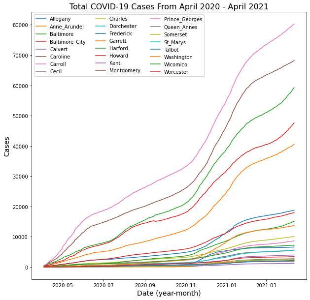

```python
# setup graph size (optional)
plt.figure(figsize = (10, 10))

# plot the data
for column in (cases_data.columns):
    plt.plot(cases_data[column], label = column)

# label the graph with a title, x-axis, y-axis, and a legend
plt.title("Total COVID-19 Cases From April 2020 - April 2021", fontsize = 16)
plt.xlabel("Date (year-month)", fontsize = 14)
plt.ylabel("Cases", fontsize = 14)
plt.legend(ncol = 3)

plt.show()
```

### Figure 1.b

Below is a line graph of deaths by county over time.

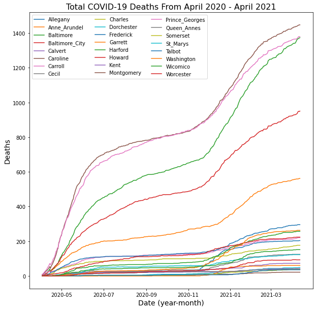

```python
# setup graph size (optional)
plt.figure(figsize = (10, 10))

# plot the data
for column in (deaths_data.columns):
    plt.plot(deaths_data[column], label = column)

# label the graph with a title, x-axis, y-axis, and a legend
plt.title("Total COVID-19 Deaths From April 2020 - April 2021", fontsize = 16)
plt.xlabel("Date (year-month)", fontsize = 14)
plt.ylabel("Deaths", fontsize = 14)
plt.legend(ncol = 3)

plt.show()
```

### Figure 1 Analysis

From what I can see from Figure 1.a and Figure 1.b there were 5 counties that's been significantly affected by COVID-19.

Since there's a lot of counties, their respective colors in the graphs are repeated so there's no definitive answer to what those 5 counties are.

As an educated guess, I would say that those 5 counties include Baltimore, Baltimore City, Prince Georges, Montgomery, and Anne Arundel.

Another observation that can be made is that since the data is cumulative, we can assume that an increasing slope means new cases and a horizontal slope means no new cases.

### The 5 Counties

A way we can find out what those 5 counties truly are is by making a scatter plot of average cases and deaths per County.

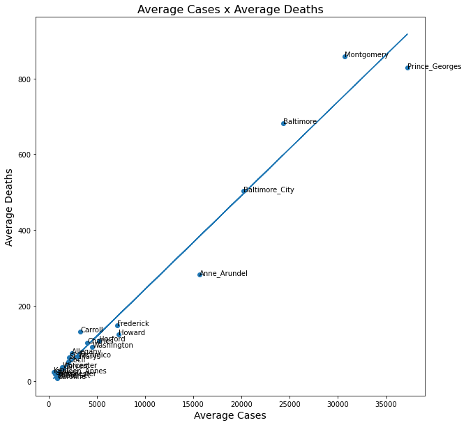

```python
avg_cases = data.groupby('County')['Cases'].mean().values
avg_deaths = data.groupby('County')['Deaths'].mean().values

# this will be useful later on in the tutorial
counties = data['County'].drop_duplicates().values

# create a dataframe of both values, useful later on
average = pd.DataFrame({'County': counties, 'Avg_Cases': avg_cases, 'Avg_Deaths': avg_deaths})

# scatterplot w/ regression line
plt.figure(figsize = (10, 10))
m, b = np.polyfit(average['Avg_Cases'], average['Avg_Deaths'], 1)
plt.plot(average['Avg_Cases'], m * average['Avg_Cases'] + b)
plt.scatter(average['Avg_Cases'], average['Avg_Deaths'])

# label each point on the graph with their respective county
for index, txt in enumerate(average['County']):
    plt.annotate(txt, (average.at[index, 'Avg_Cases'], average.at[index, 'Avg_Deaths']))

# label the graph with a title, x-axis, and y-axis
plt.title("Average Cases x Average Deaths", fontsize = 16)
plt.xlabel("Average Cases", fontsize = 14)
plt.ylabel("Average Deaths", fontsize = 14)
plt.show()
```

Based on the figure above, my educated guess was correct. The way I guessed was from narrowing down the top colors and picking the counties that would have the most population.

### Average Cases & Deaths

Next, let's visualize the average, total cases and deaths across all counties over time.

### Figure 2.a

Below is a line graph of average cases across all counties over time.

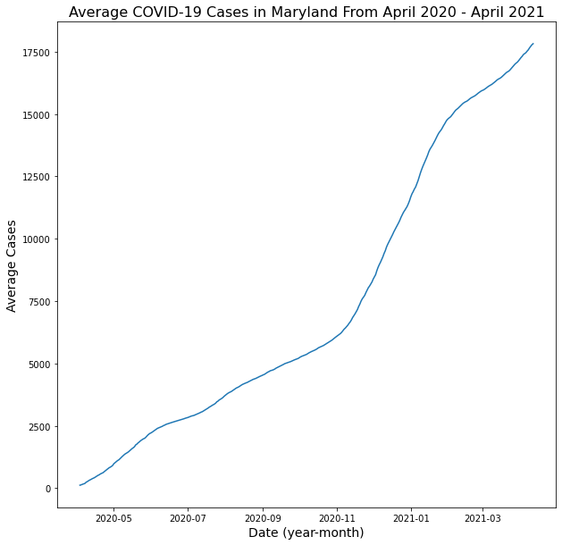

```python
avg_cases = cases_data.copy()

# calculate the average cases
for index, row in avg_cases.iterrows():
    avg_cases.at[index, 'Avg_Cases'] = row.mean()

# isolate the 'avg_cases' column
avg_cases = avg_cases[['Avg_Cases']]

# setup graph size (optional)
plt.figure(figsize = (10, 10))

# plot the data
plt.plot(avg_cases['Avg_Cases'])

# label the graph with a title, x-axis, and y-axis
plt.title("Average COVID-19 Cases in Maryland From April 2020 - April 2021", fontsize = 16)
plt.xlabel("Date (year-month)", fontsize = 14)
plt.ylabel("Average Cases", fontsize = 14)
plt.show()
```

### Figure 2.b

Below is a line graph of average deaths across all counties over time.

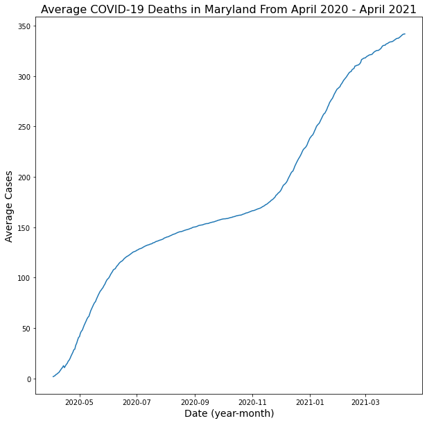

```python
avg_deaths = deaths_data.copy()

# calculate the average deaths
for index, row in avg_deaths.iterrows():
    avg_deaths.at[index, 'Avg_Deaths'] = row.mean()

# isolate the 'avg_death' column
avg_deaths = avg_deaths[['Avg_Deaths']]

# setup graph size (optional)
plt.figure(figsize = (10, 10))

# plot the data
plt.plot(avg_deaths['Avg_Deaths'])

# label the graph with a title, x-axis, and y-axis
plt.title("Average COVID-19 Deaths in Maryland From April 2020 - April 2021", fontsize = 16)
plt.xlabel("Date (year-month)", fontsize = 14)
plt.ylabel("Average Cases", fontsize = 14)
plt.show()
```

### Figure 2.c

Using a different way of plotting the graphs, we can make a twin axis graph average cases and deaths across all counties over time.

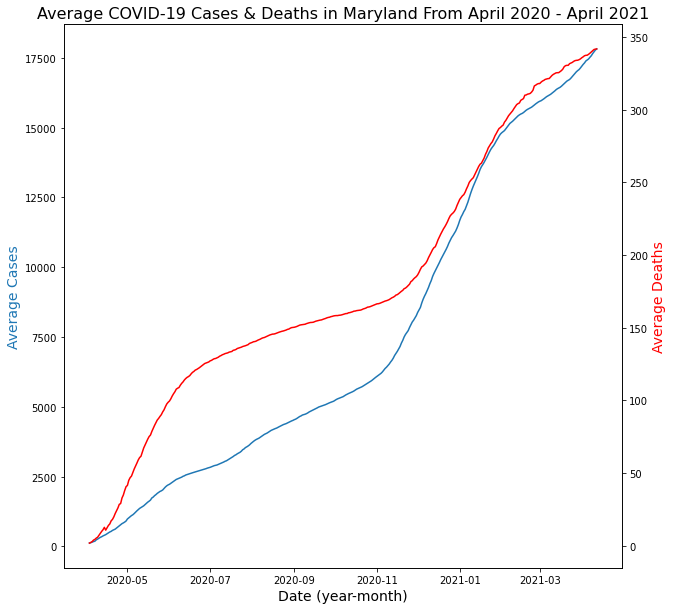

```python
# create figure and axis objects with subplots()
fig, ax = plt.subplots(figsize = (10, 10))

# plot the cases data
ax.plot(avg_cases['Avg_Cases'])

# label the graph with x-axis and y-axis
# Fun Fact: #1f77b4 is matplotlib.pyplot's default color
ax.set_xlabel("Date (year-month)", fontsize = 14)
ax.set_ylabel("Average Cases", color = '#1f77b4',fontsize = 14)

# Adding Twin Axes to plot deaths data
ax2 = ax.twinx()

# plot the deaths data
ax2.plot(avg_deaths['Avg_Deaths'], color = 'red')

# label the graph with x-axis and y-axis
ax2.set_ylabel("Average Deaths", color = 'red', fontsize = 14)

# label the graph with a title
plt.title("Average COVID-19 Cases & Deaths in Maryland From April 2020 - April 2021", fontsize = 16)

plt.show()
```

### Figure 2 Analysis

Based on Figure 2.a and Figure 2.b we can see the rate of increasing COVID-19 cases and deaths in Maryland as a whole.

In regards to COVID-19 cases in Figure 2.a, there was a steady increase of cases between April 2020 to November 2020. From then to February 2021, the steep rate of cumulative cases increased from roughly 5000 cases to a whopping 15000 cases. That's 3 times the initial 5000 case!

In regards to COVID-19 deaths in Figure 2.b, there's been a significant jump in deaths between April 2020 to June 2020 and December 2020 to March 2021. There was a steady rate of deaths between June 2020 to December 2020.

Based on Figure 2.c, we can see that despite increasing rate of cases between April 2020 to November 2020, the rate of deaths were steady between June 2020 to December 2020. This may indicate the effect of hospital's successfully treating patients of COVID-19. In addition, the period of a steady increase in cases and deaths transitioning into a steep increase in cases and deaths may indicate that the population that quarantined during the majority of 2020 started to come out and ended up catching COVID-19.

# Hypothesis Testing

Hypothsis testing is a statistical way of determining whether or not a model is a good fit. As such, there are two possible Hypothesis: A Null Hypothesis and an Alternative Hypothesis.

When testing, we want to set up our hypothesis so that it rejects the Null Hypothesis.

We can reject the Null Hypothesis by making sure that there's significance to the model. Such significance is quantified by what's known as the p-value. A p-value less than 0.05 is considered to be statistically significant, which rejects the Null Hypothesis.

Our hypothesis in regards to cases/deaths across counties is the following:

p-value = 0.05

Null Hypothesis (>p-value): No significances between County and Cases/Deaths

Alternative Hypothesis (<p-value): Significance between County and Cases/Deaths

We can find the p-value of our models using the statsmodels.formula.api library.

### The Cases Model

```python
cases_model = sm.ols(formula = "Cases ~ Days*County", data = data).fit()
cases_model.summary()
```

OLS Regression Results

| Dep. Variable: | Cases | R-squared: | 0.976 |
| --- | --- | --- | --- |
| Model: | OLS | Adj. R-squared: | 0.976 |
| Method: | Least Squares | F-statistic: | 7682. |
| Date: | Wed, 21 Jul 2021 | Prob (F-statistic): | 0.00 |
| Time: | 11:15:27 | Log-Likelihood: | -81518. |
| No. Observations: | 9000 | AIC: | 1.631e+05 |
| Df Residuals: | 8952 | BIC: | 1.635e+05 |
| Df Model: | 47 |  |  |
| Covariance Type: | nonrobust |  |  |

|  | coef | std err | t | P>\|t\| | [0.025 | 0.975] |
| --- | --- | --- | --- | --- | --- | --- |
| Intercept | -1771.6224 | 214.643 | -8.254 | 0.000 | -2192.371 | -1350.874 |
| County[T.Anne_Arundel] | -3469.6571 | 303.551 | -11.430 | 0.000 | -4064.686 | -2874.628 |
| County[T.Baltimore] | -4080.7965 | 303.551 | -13.444 | 0.000 | -4675.825 | -3485.768 |
| County[T.Baltimore_City] | -1747.1797 | 303.551 | -5.756 | 0.000 | -2342.209 | -1152.151 |
| County[T.Calvert] | 1173.2637 | 303.551 | 3.865 | 0.000 | 578.235 | 1768.292 |
| County[T.Caroline] | 1514.0947 | 303.551 | 4.988 | 0.000 | 919.066 | 2109.124 |
| County[T.Carroll] | 678.1936 | 303.551 | 2.234 | 0.025 | 83.165 | 1273.222 |
| County[T.Cecil] | 773.3816 | 303.551 | 2.548 | 0.011 | 178.353 | 1368.410 |
| County[T.Charles] | 683.5235 | 303.551 | 2.252 | 0.024 | 88.495 | 1278.552 |
| County[T.Dorchester] | 1334.5763 | 303.551 | 4.397 | 0.000 | 739.548 | 1929.605 |
| County[T.Frederick] | -839.0812 | 303.551 | -2.764 | 0.006 | -1434.110 | -244.052 |
| County[T.Garrett] | 1209.6287 | 303.551 | 3.985 | 0.000 | 614.600 | 1804.657 |
| County[T.Harford] | -667.3800 | 303.551 | -2.199 | 0.028 | -1262.409 | -72.351 |
| County[T.Howard] | -142.3601 | 303.551 | -0.469 | 0.639 | -737.389 | 452.669 |
| County[T.Kent] | 1631.3330 | 303.551 | 5.374 | 0.000 | 1036.304 | 2226.362 |
| County[T.Montgomery] | -2232.4424 | 303.551 | -7.354 | 0.000 | -2827.471 | -1637.414 |
| County[T.Prince_Georges] | -664.5927 | 303.551 | -2.189 | 0.029 | -1259.621 | -69.564 |
| County[T.Queen_Annes] | 1293.6134 | 303.551 | 4.262 | 0.000 | 698.585 | 1888.642 |
| County[T.Somerset] | 1142.2809 | 303.551 | 3.763 | 0.000 | 547.252 | 1737.310 |
| County[T.St_Marys] | 939.0950 | 303.551 | 3.094 | 0.002 | 344.066 | 1534.124 |
| County[T.Talbot] | 1444.9798 | 303.551 | 4.760 | 0.000 | 849.951 | 2040.009 |
| County[T.Washington] | -1293.5992 | 303.551 | -4.262 | 0.000 | -1888.628 | -698.570 |
| County[T.Wicomico] | 914.9828 | 303.551 | 3.014 | 0.003 | 319.954 | 1510.012 |
| County[T.Worcester] | 1226.3221 | 303.551 | 4.040 | 0.000 | 631.293 | 1821.351 |
| Days | 22.2572 | 0.993 | 22.406 | 0.000 | 20.310 | 24.204 |
| Days:County[T.Anne_Arundel] | 89.4487 | 1.405 | 63.671 | 0.000 | 86.695 | 92.203 |
| Days:County[T.Baltimore] | 139.0178 | 1.405 | 98.956 | 0.000 | 136.264 | 141.772 |
| Days:County[T.Baltimore_City] | 104.7153 | 1.405 | 74.538 | 0.000 | 101.962 | 107.469 |
| Days:County[T.Calvert] | -10.8639 | 1.405 | -7.733 | 0.000 | -13.618 | -8.110 |
| Days:County[T.Caroline] | -16.0713 | 1.405 | -11.440 | 0.000 | -18.825 | -13.317 |
| Days:County[T.Carroll] | 1.0740 | 1.405 | 0.764 | 0.445 | -1.680 | 3.828 |
| Days:County[T.Cecil] | -5.9809 | 1.405 | -4.257 | 0.000 | -8.735 | -3.227 |
| Days:County[T.Charles] | 4.9876 | 1.405 | 3.550 | 0.000 | 2.234 | 7.741 |
| Days:County[T.Dorchester] | -14.8927 | 1.405 | -10.601 | 0.000 | -17.647 | -12.139 |
| Days:County[T.Frederick] | 29.7549 | 1.405 | 21.180 | 0.000 | 27.001 | 32.509 |
| Days:County[T.Garrett] | -15.8291 | 1.405 | -11.267 | 0.000 | -18.583 | -13.075 |
| Days:County[T.Harford] | 18.7160 | 1.405 | 13.322 | 0.000 | 15.962 | 21.470 |
| Days:County[T.Howard] | 26.8944 | 1.405 | 19.144 | 0.000 | 24.141 | 29.648 |
| Days:County[T.Kent] | -18.8899 | 1.405 | -13.446 | 0.000 | -21.644 | -16.136 |
| Days:County[T.Montgomery] | 163.4494 | 1.405 | 116.346 | 0.000 | 160.696 | 166.203 |
| Days:County[T.Prince_Georges] | 189.7033 | 1.405 | 135.035 | 0.000 | 186.950 | 192.457 |
| Days:County[T.Queen_Annes] | -14.0744 | 1.405 | -10.018 | 0.000 | -16.828 | -11.321 |
| Days:County[T.Somerset] | -14.2034 | 1.405 | -10.110 | 0.000 | -16.957 | -11.450 |
| Days:County[T.St_Marys] | -6.4978 | 1.405 | -4.625 | 0.000 | -9.252 | -3.744 |
| Days:County[T.Talbot] | -16.3532 | 1.405 | -11.641 | 0.000 | -19.107 | -13.599 |
| Days:County[T.Washington] | 18.3216 | 1.405 | 13.042 | 0.000 | 15.568 | 21.075 |
| Days:County[T.Wicomico] | -1.5106 | 1.405 | -1.075 | 0.282 | -4.264 | 1.243 |
| Days:County[T.Worcester] | -11.8643 | 1.405 | -8.445 | 0.000 | -14.618 | -9.110 |

| Omnibus: | 1753.430 | Durbin-Watson: | 0.003 |
| --- | --- | --- | --- |
| Prob(Omnibus): | 0.000 | Jarque-Bera (JB): | 8558.999 |
| Skew: | -0.861 | Prob(JB): | 0.00 |
| Kurtosis: | 7.456 | Cond. No. | 1.08e+04 |

Notes:  
[1] Standard Errors assume that the covariance matrix of the errors is correctly specified.  
[2] The condition number is large, 1.08e+04. This might indicate that there are  
strong multicollinearity or other numerical problems.

### The Deaths Model

```python
deaths_model = sm.ols(formula = "Deaths ~ Days*County", data = data).fit()
deaths_model.summary()
```

OLS Regression Results

| Dep. Variable: | Deaths | R-squared: | 0.984 |
| --- | --- | --- | --- |
| Model: | OLS | Adj. R-squared: | 0.984 |
| Method: | Least Squares | F-statistic: | 1.146e+04 |
| Date: | Wed, 21 Jul 2021 | Prob (F-statistic): | 0.00 |
| Time: | 11:15:27 | Log-Likelihood: | -45395. |
| No. Observations: | 9000 | AIC: | 9.089e+04 |
| Df Residuals: | 8952 | BIC: | 9.123e+04 |
| Df Model: | 47 |  |  |
| Covariance Type: | nonrobust |  |  |

|  | coef | std err | t | P>\|t\| | [0.025 | 0.975] |
| --- | --- | --- | --- | --- | --- | --- |
| Intercept | -44.5661 | 3.878 | -11.492 | 0.000 | -52.168 | -36.964 |
| County[T.Anne_Arundel] | 85.3340 | 5.484 | 15.560 | 0.000 | 74.584 | 96.084 |
| County[T.Baltimore] | 105.6686 | 5.484 | 19.268 | 0.000 | 94.918 | 116.419 |
| County[T.Baltimore_City] | 117.8869 | 5.484 | 21.496 | 0.000 | 107.137 | 128.637 |
| County[T.Calvert] | 46.5063 | 5.484 | 8.480 | 0.000 | 35.756 | 57.257 |
| County[T.Caroline] | 40.9782 | 5.484 | 7.472 | 0.000 | 30.228 | 51.728 |
| County[T.Carroll] | 90.1861 | 5.484 | 16.445 | 0.000 | 79.436 | 100.936 |
| County[T.Cecil] | 34.8615 | 5.484 | 6.357 | 0.000 | 24.111 | 45.612 |
| County[T.Charles] | 82.1986 | 5.484 | 14.988 | 0.000 | 71.448 | 92.949 |
| County[T.Dorchester] | 36.5867 | 5.484 | 6.671 | 0.000 | 25.836 | 47.337 |
| County[T.Frederick] | 73.4270 | 5.484 | 13.389 | 0.000 | 62.677 | 84.177 |
| County[T.Garrett] | 25.4176 | 5.484 | 4.635 | 0.000 | 14.667 | 36.168 |
| County[T.Harford] | 26.6160 | 5.484 | 4.853 | 0.000 | 15.866 | 37.366 |
| County[T.Howard] | 61.5533 | 5.484 | 11.224 | 0.000 | 50.803 | 72.304 |
| County[T.Kent] | 52.4518 | 5.484 | 9.564 | 0.000 | 41.702 | 63.202 |
| County[T.Montgomery] | 306.0836 | 5.484 | 55.812 | 0.000 | 295.333 | 316.834 |
| County[T.Prince_Georges] | 301.1855 | 5.484 | 54.919 | 0.000 | 290.435 | 311.936 |
| County[T.Queen_Annes] | 51.6477 | 5.484 | 9.418 | 0.000 | 40.897 | 62.398 |
| County[T.Somerset] | 37.0369 | 5.484 | 6.753 | 0.000 | 26.287 | 47.787 |
| County[T.St_Marys] | 49.8284 | 5.484 | 9.086 | 0.000 | 39.078 | 60.579 |
| County[T.Talbot] | 38.4996 | 5.484 | 7.020 | 0.000 | 27.749 | 49.250 |
| County[T.Washington] | -8.2430 | 5.484 | -1.503 | 0.133 | -18.993 | 2.507 |
| County[T.Wicomico] | 38.0907 | 5.484 | 6.946 | 0.000 | 27.340 | 48.841 |
| County[T.Worcester] | 33.1865 | 5.484 | 6.051 | 0.000 | 22.436 | 43.937 |
| Days | 0.6329 | 0.018 | 35.262 | 0.000 | 0.598 | 0.668 |
| Days:County[T.Anne_Arundel] | 0.6590 | 0.025 | 25.964 | 0.000 | 0.609 | 0.709 |
| Days:County[T.Baltimore] | 2.6882 | 0.025 | 105.913 | 0.000 | 2.638 | 2.738 |
| Days:County[T.Baltimore_City] | 1.6611 | 0.025 | 65.447 | 0.000 | 1.611 | 1.711 |
| Days:County[T.Calvert] | -0.4574 | 0.025 | -18.022 | 0.000 | -0.507 | -0.408 |
| Days:County[T.Caroline] | -0.5708 | 0.025 | -22.488 | 0.000 | -0.621 | -0.521 |
| Days:County[T.Carroll] | -0.1764 | 0.025 | -6.950 | 0.000 | -0.226 | -0.127 |
| Days:County[T.Cecil] | -0.3052 | 0.025 | -12.023 | 0.000 | -0.355 | -0.255 |
| Days:County[T.Charles] | -0.2900 | 0.025 | -11.426 | 0.000 | -0.340 | -0.240 |
| Days:County[T.Dorchester] | -0.5049 | 0.025 | -19.893 | 0.000 | -0.555 | -0.455 |
| Days:County[T.Frederick] | 0.0069 | 0.025 | 0.270 | 0.787 | -0.043 | 0.057 |
| Days:County[T.Garrett] | -0.4329 | 0.025 | -17.057 | 0.000 | -0.483 | -0.383 |
| Days:County[T.Harford] | 0.0312 | 0.025 | 1.231 | 0.218 | -0.019 | 0.081 |
| Days:County[T.Howard] | -0.0614 | 0.025 | -2.420 | 0.016 | -0.111 | -0.012 |
| Days:County[T.Kent] | -0.5475 | 0.025 | -21.571 | 0.000 | -0.597 | -0.498 |
| Days:County[T.Montgomery] | 2.5561 | 0.025 | 100.709 | 0.000 | 2.506 | 2.606 |
| Days:County[T.Prince_Georges] | 2.4298 | 0.025 | 95.731 | 0.000 | 2.380 | 2.480 |
| Days:County[T.Queen_Annes] | -0.5439 | 0.025 | -21.428 | 0.000 | -0.594 | -0.494 |
| Days:County[T.Somerset] | -0.5314 | 0.025 | -20.938 | 0.000 | -0.581 | -0.482 |
| Days:County[T.St_Marys] | -0.3230 | 0.025 | -12.727 | 0.000 | -0.373 | -0.273 |
| Days:County[T.Talbot] | -0.5441 | 0.025 | -21.436 | 0.000 | -0.594 | -0.494 |
| Days:County[T.Washington] | 0.1296 | 0.025 | 5.106 | 0.000 | 0.080 | 0.179 |
| Days:County[T.Wicomico] | -0.2494 | 0.025 | -9.825 | 0.000 | -0.299 | -0.200 |
| Days:County[T.Worcester] | -0.3732 | 0.025 | -14.705 | 0.000 | -0.423 | -0.323 |

| Omnibus: | 2669.455 | Durbin-Watson: | 0.015 |
| --- | --- | --- | --- |
| Prob(Omnibus): | 0.000 | Jarque-Bera (JB): | 38698.080 |
| Skew: | -1.021 | Prob(JB): | 0.00 |
| Kurtosis: | 12.951 | Cond. No. | 1.08e+04 |

Notes:  
[1] Standard Errors assume that the covariance matrix of the errors is correctly specified.  
[2] The condition number is large, 1.08e+04. This might indicate that there are  
strong multicollinearity or other numerical problems.

Based on The Cases Model, under the "P>|t|" column, we can reject the Null Hypothesis for COVID-19 cases among the majority of the counties. Counties that has no significance include Howard, Carroll, and Wicomico.

Based on The Deaths Model, under the "P>|t|" column, we can reject the Null Hypothesis for COVID-19 deaths among the majority of the counties. Counties that has no significance include Washington, Frederick, and Harford.

As such we continue with a Hypothesis that the amount of days since the first day of reporting correlates with COVID-19 Cases and Deaths in each county.

# Machine Learning

The most simplest way of approaching this is to use linear regression on all counties.

Set up our independent and dependent variables into dataframes.

```python
ind_c_d = data.pivot(index = 'Days', columns = 'County', values = 'Days')

dep_c = data.pivot(index = 'Days', columns = 'County', values = 'Cases')

dep_d = data.pivot(index = 'Days', columns = 'County', values = 'Deaths')
```

Split the dataset into random testing and training sets.

```python
cases_ind_train, cases_ind_test, cases_dep_train, cases_dep_test = ms.train_test_split(ind_c_d, dep_c)

deaths_ind_train, deaths_ind_test, deaths_dep_train, deaths_dep_test = ms.train_test_split(ind_c_d, dep_d)
```

Define the linear regression models.

```python
cases_linear = LinearRegression()

deaths_linear = LinearRegression()
```

Fit our trained independent and dependent sets.

```python
cases_linear.fit(cases_ind_train, cases_dep_train)

deaths_linear.fit(deaths_ind_train, deaths_dep_train)
```

```
LinearRegression()
```

See how well our linear regression predicted COVID-19 cases/deaths in Maryland using an algorithm call 10-fold cross-validation.

```python
cases_cv = ms.cross_val_score(cases_linear, cases_ind_train, cases_dep_train, cv = 10)
deaths_cv = ms.cross_val_score(deaths_linear, deaths_ind_train, deaths_dep_train, cv = 10)

# Accuracy and Error Estimate
print("10-Fold CV Accuracy on Cases: {}%".format(round(np.mean(cases_cv) * 100, 1)))
print("10-fold CV Error Estimate on Cases: {}\n".format(round(np.std(cases_cv), 4)))

print("10-Fold CV Accuracy on Deaths: {}%".format(round(np.mean(deaths_cv) * 100, 1)))
print("10-fold CV Error Estimate on Deaths: {}".format(round(np.std(deaths_cv), 4)))
```

```
10-Fold CV Accuracy on Cases: 88.4%
10-fold CV Error Estimate on Cases: 0.0313

10-Fold CV Accuracy on Deaths: 86.0%
10-fold CV Error Estimate on Deaths: 0.0245
```

# Conclusion

Congratulations! This tutorial walked you through "The Data Science Pipeline," containing Data Collection, Data Management, Data Representation, Exploratory Data Analysis, Hypothesis Testing, Maching Learning, and Communication of Insights Attained/Conclusion.

From what we have learned based on COVID-19 Cases and Deaths, there are periods of time where cases and deaths slow down but then suddenly increase. These periods can indicate the movement of the population such that the slow down of cases and deaths are caused by quarantining while the sudden increase are caused by going out of quarantine or not following [CDC Guidelines](https://www.cdc.gov/coronavirus/2019-ncov/communication/guidance.html).

Using a line graph, we can see which counties have been most affected by COVID-19 and the movement of their respective population.

While the vaccine is accessible to the public, COVID-19 still prevails. As such, we must do our part to follow [CDC Guidelines](https://www.cdc.gov/coronavirus/2019-ncov/communication/guidance.html) and make sure to get vaccinated as soon as possible.

# References

Source of data inspiration:  
[Maryland news article](https://www.marylandmatters.org/2021/04/05/hogan-moves-to-open-the-vaccine-floodgates-expands-access-to-everyone-16-and-older/)

Data Downloads:  
[MD COVID-19 - Cases by County](https://opendata.maryland.gov/Health-and-Human-Services/MD-COVID-19-Cases-by-County/tm86-dujs)

[MD COVID-19 - Confirmed Deaths by County](https://opendata.maryland.gov/Health-and-Human-Services/MD-COVID-19-Confirmed-Deaths-by-County/x28q-kc4a)

Setup Requirements:  
[Python 3 Download](https://www.python.org/downloads/)

[Anaconda Download](https://www.anaconda.com/products/individual)

[Jupyter Notebook Download part 1/2](https://www.geeksforgeeks.org/how-to-install-jupyter-notebook-in-windows/) and [Jupyter Notebook Download part 2/2](https://jupyter.org/install)

Approach Topics:  
[Introduction to Pandas](https://pandas.pydata.org/pandas-docs/stable/getting_started/intro_tutorials/01_table_oriented.html#min-tut-01-tableoriented)

[Pyplot Tutorial](https://matplotlib.org/stable/tutorials/introductory/pyplot.html)

[Pyplot Twin Axis](https://www.geeksforgeeks.org/matplotlib-pyplot-twinx-in-python/)

[A Course in Machine Learning](http://ciml.info)

[Implementing Linear Regression Using sklearn](https://heartbeat.fritz.ai/implementing-multiple-linear-regression-using-sklearn-43b3d3f2fe8b)

[10-fold Cross Validation](https://towardsdatascience.com/complete-guide-to-pythons-cross-validation-with-examples-a9676b5cac12)

Stay Safe:  
[CDC Guidelines](https://www.cdc.gov/coronavirus/2019-ncov/communication/guidance.html)

Other:  
[Jupyter Notebook Markdown Cheatsheet](https://www.ibm.com/docs/en/watson-studio-local/1.2.3?topic=notebooks-markdown-jupyter-cheatsheet)